# Overview

This is a very quick run-through of some basic statistical concepts, adapted from [Lab 4 in Harvard's CS109](https://github.com/cs109/2015lab4) course. Please feel free to try the original lab if you're feeling ambitious :-) The CS109 git repository also has the solutions if you're stuck.

- Linear Regression Models
- Prediction using linear regression

Linear regression is used to model and predict continuous outcomes with normal random errors. There are nearly an infinite number of different types of regression models and each regression model is typically defined by the distribution of the prediction errors (called "residuals") of the type of data. Logistic regression is used to model binary outcomes whereas Poisson regression is used to predict counts. In this exercise, we'll see some examples of linear regression as well as Train-test splits.

The packages we'll cover are: `statsmodels`, `seaborn`, and `scikit-learn`. While we don't explicitly teach `statsmodels` and `seaborn` in the Springboard workshop, those are great libraries to know.

[figure not shown]

```python
# special IPython command to prepare the notebook for matplotlib and other libraries
%matplotlib inline

import numpy as np
import pandas as pd
import scipy.stats as stats
import matplotlib.pyplot as plt
import sklearn
import pprint

import seaborn as sns

# special matplotlib argument for improved plots
from matplotlib import rcParams
sns.set_style("whitegrid")
sns.set_context("poster")
```

# 1. Introduction to Linear Regression

## 1.1. Purpose of linear regression

Given a dataset containing predictor variables $X$ and outcome/response variable $Y$, linear regression can be used to:

- Build a **predictive model** to predict future values of $\hat{Y}$, using new data $X^*$ where $Y$ is unknown.
- Model the **strength of the relationship** between each independent variable $X_i$ and $Y$
- Many times, only a subset of independent variables $X_i$ will have a linear relationship with $Y$
- Need to figure out which $X_i$ contributes most information to predict $Y$
- It is in many cases, the first pass prediction algorithm for continuous outcomes.

## 1.2. A Brief Mathematical Recap

[Linear Regression](http://en.wikipedia.org/wiki/Linear_regression) is a method to model the relationship between a set of independent variables $X$ (also knowns as explanatory variables, features, predictors) and a dependent variable $Y$. This method assumes the relationship between each predictor $X$ is **linearly** related to the dependent variable $Y$. The most basic linear regression model contains one independent variable $X$, we'll call this the simple model.

$$ Y = \beta_0 + \beta_1 X + \epsilon$$

where $\epsilon$ is considered as an unobservable random variable that adds noise to the linear relationship. In linear regression, $\epsilon$ is assumed to be normally distributed with a mean of 0. In other words, what this means is that on average, if we know $Y$, a roughly equal number of predictions $\hat{Y}$ will be above $Y$ and others will be below $Y$. That is, on average, the error is zero. The residuals, $\epsilon$ are also assumed to be "i.i.d.": independently and identically distributed. Independence means that the residuals are not correlated -- the residual from one prediction has no effect on the residual from another prediction. Correlated errors are common in time series analysis and spatial analyses.

- $\beta_0$ is the intercept of the linear model and represents the average of $Y$ when all independent variables $X$ are set to 0.
- $\beta_1$ is the slope of the line associated with the regression model and represents the average effect of a one-unit increase in $X$ on $Y$.
- Back to the simple model. The model in linear regression is the *conditional mean* of $Y$ given the values in $X$ is expressed a linear function.

$$ y = f(x) = E(Y | X = x)$$

[figure not shown]

*Image from http://www.learner.org/courses/againstallodds/about/glossary.html. Note this image uses $\alpha$ and $\beta$ instead of $\beta_0$ and $\beta_1$.*

- The goal is to estimate the coefficients (e.g. $\beta_0$ and $\beta_1$). We represent the estimates of the coefficients with a "hat" on top of the letter.

$$ \hat{\beta}_0, \hat{\beta}_1 $$

- Once we estimate the coefficients $\hat{\beta}_0$ and $\hat{\beta}_1$, we can use these to predict new values of $Y$ given new data $X$.

$$\hat{y} = \hat{\beta}_0 + \hat{\beta}_1 x_1$$

- Multiple linear regression is when you have more than one independent variable and the estimation involves matrices
  - $X_1$, $X_2$, $X_3$, $\ldots$
- How do you estimate the coefficients?
  - There are many ways to fit a linear regression model
  - The method called **least squares** is the most common methods
  - We will discuss least squares

$$ Y = \beta_0 + \beta_1 X_1 + \ldots + \beta_p X_p + \epsilon$$

## 1.3. Estimating $\hat\beta$: Least squares

[Least squares](http://en.wikipedia.org/wiki/Least_squares) is a method that can estimate the coefficients of a linear model by minimizing the squared residuals:

$$ \mathscr{L} = \sum_{i=1}^N \epsilon_i^2 = \sum_{i=1}^N \left( y_i - \hat{y}_i \right)^2 = \sum_{i=1}^N \left(y_i - \left(\beta_0 + \beta_1 x_i\right)\right)^2 $$

where $N$ is the number of observations and $\epsilon$ represents a residual or error, ACTUAL - PREDICTED.

#### Estimating the intercept $\hat{\beta_0}$ for the simple linear model

We want to minimize the squared residuals and solve for $\hat{\beta_0}$ so we take the partial derivative of $\mathscr{L}$ with respect to $\hat{\beta_0}$

$ \begin{align} \frac{\partial \mathscr{L}}{\partial \hat{\beta_0}} &= \frac{\partial}{\partial \hat{\beta_0}} \sum_{i=1}^N \epsilon^2 \\ &= \frac{\partial}{\partial \hat{\beta_0}} \sum_{i=1}^N \left( y_i - \hat{y}_i \right)^2 \\ &= \frac{\partial}{\partial \hat{\beta_0}} \sum_{i=1}^N \left( y_i - \left( \hat{\beta}_0 + \hat{\beta}_1 x_i \right) \right)^2 \\ &= -2 \sum_{i=1}^N \left( y_i - \left( \hat{\beta}_0 + \hat{\beta}_1 x_i \right) \right) \hspace{25mm} \mbox{(by chain rule)} \\ &= -2 \sum_{i=1}^N (y_i - \hat{\beta}_0 - \hat{\beta}_1 x_i) \\ &= -2 \left[ \left( \sum_{i=1}^N y_i \right) - N \hat{\beta_0} - \hat{\beta}_1 \left( \sum_{i=1}^N x_i \right) \right] \\ & 2 \left[ N \hat{\beta}_0 + \hat{\beta}_1 \sum_{i=1}^N x_i - \sum_{i=1}^N y_i \right] = 0 \hspace{20mm} \mbox{(Set equal to 0 and solve for $\hat{\beta}_0$)} \\ & N \hat{\beta}_0 + \hat{\beta}_1 \sum_{i=1}^N x_i - \sum_{i=1}^N y_i = 0 \\ & N \hat{\beta}_0 = \sum_{i=1}^N y_i - \hat{\beta}_1 \sum_{i=1}^N x_i \\ & \hat{\beta}_0 = \frac{\sum_{i=1}^N y_i - \hat{\beta}_1 \sum_{i=1}^N x_i}{N} \\ & \hat{\beta}_0 = \frac{\sum_{i=1}^N y_i}{N} - \hat{\beta}_1 \frac{\sum_{i=1}^N x_i}{N} \\ & \boxed{\hat{\beta}_0 = \bar{y} - \hat{\beta}_1 \bar{x}} \end{align} $

Using this new information, we can compute the estimate for $\hat{\beta}_1$ by taking the partial derivative of $\mathscr{L}$ with respect to $\hat{\beta}_1$.

$ \begin{align} \frac{\partial \mathscr{L}}{\partial \hat{\beta_1}} &= \frac{\partial}{\partial \hat{\beta_1}} \sum_{i=1}^N \epsilon^2 \\ &= \frac{\partial}{\partial \hat{\beta_1}} \sum_{i=1}^N \left( y_i - \hat{y}_i \right)^2 \\ &= \frac{\partial}{\partial \hat{\beta_1}} \sum_{i=1}^N \left( y_i - \left( \hat{\beta}_0 + \hat{\beta}_1 x_i \right) \right)^2 \\ &= 2 \sum_{i=1}^N \left( y_i - \left( \hat{\beta}_0 + \hat{\beta}_1 x_i \right) \right) \left( -x_i \right) \hspace{25mm}\mbox{(by chain rule)} \\ &= -2 \sum_{i=1}^N x_i \left( y_i - \hat{\beta}_0 - \hat{\beta}_1 x_i \right) \\ &= -2 \sum_{i=1}^N x_i (y_i - \hat{\beta}_0 x_i - \hat{\beta}_1 x_i^2) \\ &= -2 \sum_{i=1}^N x_i (y_i - \left( \bar{y} - \hat{\beta}_1 \bar{x} \right) x_i - \hat{\beta}_1 x_i^2) \\ &= -2 \sum_{i=1}^N (x_i y_i - \bar{y}x_i + \hat{\beta}_1\bar{x}x_i - \hat{\beta}_1 x_i^2) \\ &= -2 \left[ \sum_{i=1}^N x_i y_i - \bar{y} \sum_{i=1}^N x_i + \hat{\beta}_1\bar{x}\sum_{i=1}^N x_i - \hat{\beta}_1 \sum_{i=1}^N x_i^2 \right] \\ &= -2 \left[ \hat{\beta}_1 \left\{ \bar{x} \sum_{i=1}^N x_i - \sum_{i=1}^N x_i^2 \right\} + \left\{ \sum_{i=1}^N x_i y_i - \bar{y} \sum_{i=1}^N x_i \right\}\right] \\ & 2 \left[ \hat{\beta}_1 \left\{ \sum_{i=1}^N x_i^2 - \bar{x} \sum_{i=1}^N x_i \right\} + \left\{ \bar{y} \sum_{i=1}^N x_i - \sum_{i=1}^N x_i y_i \right\} \right] = 0 \\ & \hat{\beta}_1 = \frac{-\left( \bar{y} \sum_{i=1}^N x_i - \sum_{i=1}^N x_i y_i \right)}{\sum_{i=1}^N x_i^2 - \bar{x}\sum_{i=1}^N x_i} \\ &= \frac{\sum_{i=1}^N x_i y_i - \bar{y} \sum_{i=1}^N x_i}{\sum_{i=1}^N x_i^2 - \bar{x} \sum_{i=1}^N x_i} \\ & \boxed{\hat{\beta}_1 = \frac{\sum_{i=1}^N x_i y_i - \bar{x}\bar{y}n}{\sum_{i=1}^N x_i^2 - n \bar{x}^2}} \end{align} $

The solution can be written in compact matrix notation as

$$\hat\beta = (X^T X)^{-1}X^T Y$$

We wanted to show you this in case you remember linear algebra, in order for this solution to exist we need $X^T X$ to be invertible. Of course this requires a few extra assumptions, $X$ must be full rank so that $X^T X$ is invertible, etc. Basically, $X^T X$ is full rank if all rows and columns are linearly independent. This has a loose relationship to variables and observations being independent respective. **This is important for us because this means that having redundant features in our regression models will lead to poorly fitting (and unstable) models.** We'll see an implementation of this in the extra linear regression example.

# 2. Exploratory Data Analysis for Linear Relationships

The [Boston Housing data set](https://archive.ics.uci.edu/ml/datasets/Housing) contains information about the housing values in suburbs of Boston. This dataset was originally taken from the StatLib library which is maintained at Carnegie Mellon University and is now available on the UCI Machine Learning Repository.

## 2.1. Load the Boston Housing data set from `sklearn`

This data set is available in the [sklearn](http://scikit-learn.org/stable/modules/generated/sklearn.datasets.load_boston.html#sklearn.datasets.load_boston) python module which is how we will access it today.

```python
from sklearn.datasets import load_boston
import pandas as pd

boston = load_boston()
boston.keys()
```

```
dict_keys(['data', 'target', 'feature_names', 'DESCR', 'filename'])
```

```python
# Print description of Boston housing data set
print(boston.DESCR)
```

```
.. _boston_dataset:

Boston house prices dataset
---------------------------

**Data Set Characteristics:**

    :Number of Instances: 506

    :Number of Attributes: 13 numeric/categorical predictive. Median Value (attribute 14) is usually the target.

    :Attribute Information (in order):
        - CRIM     per capita crime rate by town
        - ZN       proportion of residential land zoned for lots over 25,000 sq.ft.
        - INDUS    proportion of non-retail business acres per town
        - CHAS     Charles River dummy variable (= 1 if tract bounds river; 0 otherwise)
        - NOX      nitric oxides concentration (parts per 10 million)
        - RM       average number of rooms per dwelling
        - AGE      proportion of owner-occupied units built prior to 1940
        - DIS      weighted distances to five Boston employment centres
        - RAD      index of accessibility to radial highways
        - TAX      full-value property-tax rate per $10,000
        - PTRATIO  pupil-teacher ratio by town
        - B        1000(Bk - 0.63)^2 where Bk is the proportion of blacks by town
        - LSTAT    % lower status of the population
        - MEDV     Median value of owner-occupied homes in $1000's

    :Missing Attribute Values: None

    :Creator: Harrison, D. and Rubinfeld, D.L.

This is a copy of UCI ML housing dataset.
https://archive.ics.uci.edu/ml/machine-learning-databases/housing/


This dataset was taken from the StatLib library which is maintained at Carnegie Mellon University.

The Boston house-price data of Harrison, D. and Rubinfeld, D.L. 'Hedonic
prices and the demand for clean air', J. Environ. Economics & Management,
vol.5, 81-102, 1978.   Used in Belsley, Kuh & Welsch, 'Regression diagnostics
...', Wiley, 1980.   N.B. Various transformations are used in the table on
pages 244-261 of the latter.

The Boston house-price data has been used in many machine learning papers that address regression
problems.

.. topic:: References

   - Belsley, Kuh & Welsch, 'Regression diagnostics: Identifying Influential Data and Sources of Collinearity', Wiley, 1980. 244-261.
   - Quinlan,R. (1993). Combining Instance-Based and Model-Based Learning. In Proceedings on the Tenth International Conference of Machine Learning, 236-243, University of Massachusetts, Amherst. Morgan Kaufmann.
```

Now let's explore the data set itself.

```python
# load features into bos DataFrame
bos = pd.DataFrame(boston.data)
# label features
bos.columns = boston.feature_names
# add price column
bos['PRICE'] = boston.target

bos.head()
```

|  | CRIM | ZN | INDUS | CHAS | NOX | RM | AGE | DIS | RAD | TAX | PTRATIO | B | LSTAT | PRICE |
| --- | --- | --- | --- | --- | --- | --- | --- | --- | --- | --- | --- | --- | --- | --- |
| 0 | 0.00632 | 18.0 | 2.31 | 0.0 | 0.538 | 6.575 | 65.2 | 4.0900 | 1.0 | 296.0 | 15.3 | 396.90 | 4.98 | 24.0 |
| 1 | 0.02731 | 0.0 | 7.07 | 0.0 | 0.469 | 6.421 | 78.9 | 4.9671 | 2.0 | 242.0 | 17.8 | 396.90 | 9.14 | 21.6 |
| 2 | 0.02729 | 0.0 | 7.07 | 0.0 | 0.469 | 7.185 | 61.1 | 4.9671 | 2.0 | 242.0 | 17.8 | 392.83 | 4.03 | 34.7 |
| 3 | 0.03237 | 0.0 | 2.18 | 0.0 | 0.458 | 6.998 | 45.8 | 6.0622 | 3.0 | 222.0 | 18.7 | 394.63 | 2.94 | 33.4 |
| 4 | 0.06905 | 0.0 | 2.18 | 0.0 | 0.458 | 7.147 | 54.2 | 6.0622 | 3.0 | 222.0 | 18.7 | 396.90 | 5.33 | 36.2 |

**Summary Statistics**  
Let's explore this data set. First we use `describe()` to get basic summary statistics for each of the columns.

```python
bos.describe()
```

|  | CRIM | ZN | INDUS | CHAS | NOX | RM | AGE | DIS | RAD | TAX | PTRATIO | B | LSTAT | PRICE |
| --- | --- | --- | --- | --- | --- | --- | --- | --- | --- | --- | --- | --- | --- | --- |
| count | 506.000000 | 506.000000 | 506.000000 | 506.000000 | 506.000000 | 506.000000 | 506.000000 | 506.000000 | 506.000000 | 506.000000 | 506.000000 | 506.000000 | 506.000000 | 506.000000 |
| mean | 3.613524 | 11.363636 | 11.136779 | 0.069170 | 0.554695 | 6.284634 | 68.574901 | 3.795043 | 9.549407 | 408.237154 | 18.455534 | 356.674032 | 12.653063 | 22.532806 |
| std | 8.601545 | 23.322453 | 6.860353 | 0.253994 | 0.115878 | 0.702617 | 28.148861 | 2.105710 | 8.707259 | 168.537116 | 2.164946 | 91.294864 | 7.141062 | 9.197104 |
| min | 0.006320 | 0.000000 | 0.460000 | 0.000000 | 0.385000 | 3.561000 | 2.900000 | 1.129600 | 1.000000 | 187.000000 | 12.600000 | 0.320000 | 1.730000 | 5.000000 |
| 25% | 0.082045 | 0.000000 | 5.190000 | 0.000000 | 0.449000 | 5.885500 | 45.025000 | 2.100175 | 4.000000 | 279.000000 | 17.400000 | 375.377500 | 6.950000 | 17.025000 |
| 50% | 0.256510 | 0.000000 | 9.690000 | 0.000000 | 0.538000 | 6.208500 | 77.500000 | 3.207450 | 5.000000 | 330.000000 | 19.050000 | 391.440000 | 11.360000 | 21.200000 |
| 75% | 3.677083 | 12.500000 | 18.100000 | 0.000000 | 0.624000 | 6.623500 | 94.075000 | 5.188425 | 24.000000 | 666.000000 | 20.200000 | 396.225000 | 16.955000 | 25.000000 |
| max | 88.976200 | 100.000000 | 27.740000 | 1.000000 | 0.871000 | 8.780000 | 100.000000 | 12.126500 | 24.000000 | 711.000000 | 22.000000 | 396.900000 | 37.970000 | 50.000000 |

## 2.2. Scatterplots: House Price Relationships

Analyze relationships between different features of a house and its price through the use of scatterplots.

### 2.2.1. Crime Rate

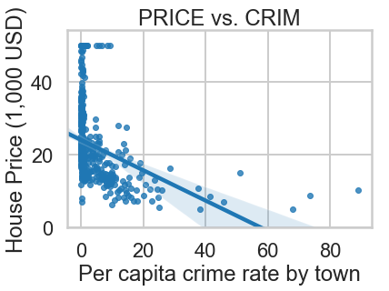

```
$50,000 priced homes' crime rate range: 0.01 - 9.23
```

```python
sns.regplot(y="PRICE", x="CRIM", data=bos, marker='.')
plt.xlabel("Per capita crime rate by town")
plt.ylabel("House Price (1,000 USD)")
plt.title("PRICE vs. CRIM")
plt.ylim(0)

plt.show()

exp_cr = np.array(bos.CRIM[bos.PRICE == 50])
ec_min = min(exp_cr)
ec_max = max(exp_cr)
print("\n$50,000 priced homes' crime rate range: {:.2f} - {:.2f}".format(ec_min, ec_max))
```

**Crime Rate Analysis**

> There is a non linear relationship between the housing price and the per capita crime rate. As it can be seen from the scatter plot above, the price of a house cannot get over a price of \$20,000 if the crime rate value is above 20. The price of houses is allowed to grow to a max of $50,000 only when the crime rate drops close to zero. However, some of the most expensive houses see crime rates close to 10; this means that crime rate is not the only thing that is taken into consideration when determining the price of a house. Therefore, other features have to be taken into consideration and analyzed. Below we will explore other house features' relationship with the house's price.

### 2.2.2. Number of Rooms

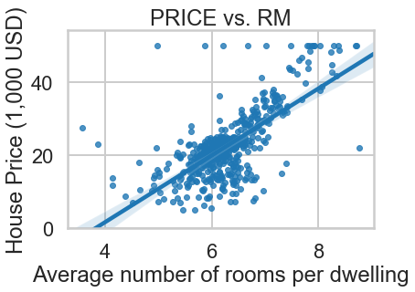

```
$50,000 priced homes' average no. of rooms range: 4.97 - 8.725
```

```python
sns.regplot(y="PRICE", x="RM", data=bos, marker='.')
plt.xlabel("Average number of rooms per dwelling")
plt.ylabel("House Price (1,000 USD)")
plt.title("PRICE vs. RM")
plt.ylim(0)
plt.show()

exp_room = np.array(bos.RM[bos.PRICE == 50])
er_min = min(exp_room)
er_max = max(exp_room)
print("\n$50,000 priced homes' average no. of rooms range: {} - {}".format(er_min, er_max))
```

**No. of Rooms Analysis**

> The relationship between the number of rooms in a house and its price is directly proportional, or positively linear; this relationship is more linear than the one between crime rate and house price. However, the housing price vs. average number of rooms scatterplot still shows a discrepancy when you get to the most expensive houses, becasue houses are able to achieve a maximum price of \$50,000 with an average of about 5 rooms which is on the lower end of the spectrum. This further confirms that a single house feature does not give the full picture regarding what constitutes the price of a house, and a combination of multiple house features will have to be used by the fitted model to deduce a nuanced, accurate house price.

### 2.2.3. Pupil-Teacher Ratio

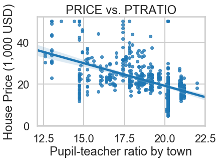

```python
sns.regplot(y="PRICE", x="PTRATIO", data=bos, marker='.')
plt.xlabel("Pupil-teacher ratio by town")
plt.ylabel("House Price (1,000 USD)")
plt.title("PRICE vs. PTRATIO")
plt.ylim(0)
plt.show()
```

**Pupil-Teacher Ratio Analysis**

> The pupil-teacher ratio tells us how many students a single teacher is responsible for, and therefore, the higher the ratio the more students a single teacher is responsible for; a lower ratio is conducive for a better education, because each student will get more time with direct mentorship from the teacher. However, more teachers means a higher cost of schooling and is paid for by the community; therefore, it makes sense that a lower PT ratio will lead to higher house prices. This conclusion can be observed in the scatterplot above; the relationship between the PT ratio and the house price is more variant than the relationships previously observed but can still be seen. As the PT ratio value decreases the prices of the houses increase; in other words, there is an inversely proportional relationship between the PT ratio and house price.

### 2.2.4. Lower Status

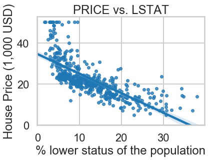

```python
sns.regplot(y="PRICE", x="LSTAT", data=bos, marker='.')
plt.xlabel("% lower status of the population")
plt.ylabel("House Price (1,000 USD)")
plt.title("PRICE vs. LSTAT")
plt.ylim(0)
plt.show()
```

**Lower Status Analysis**

> The relationship between the percentage of the population that is considered lower status and the house price is one of the clearest seen so far. As it can be seen above, as the percentage of the population considered to be of lower status increases, the price of the house decreases. The relationship is not linearly defined, but can be easily represented by a reciprocal function; the house prices drop rapidly as LSTAT percentages increase at the lower end of the LSTAT percentage range but begin leveling out as LSTAT percentages increase to the higher end of the LSTAT percentage range.

### 2.2.5. Accessibility to Radial Highways

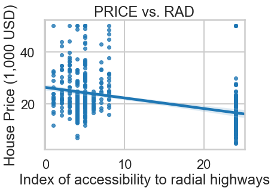

```python
sns.regplot(y="PRICE", x="RAD", data=bos, marker='.')
plt.xlabel("Index of accessibility to radial highways")
plt.ylabel("House Price (1,000 USD)")
plt.title("PRICE vs. RAD")
plt.show()
```

## 2.3. Feature Histograms

Look for correlations between houses' features using histograms.

### 2.3.1. Crime Rate: Non-Log vs. Log

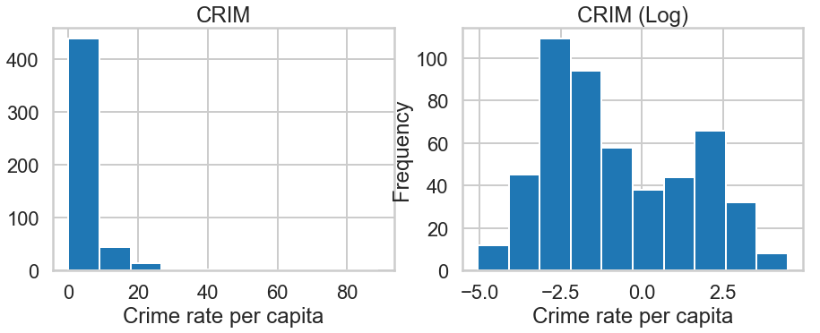

```python
h_CRIM, (H2, H1) = plt.subplots(ncols=2)
h_CRIM.set_size_inches(15,5)

H1.hist(np.log(bos.CRIM))
H1.set_title("CRIM (Log)")
H1.set_xlabel("Crime rate per capita")
H1.set_ylabel("Frequency")

H2.hist(bos.CRIM)
H2.set_title("CRIM")
H2.set_xlabel("Crime rate per capita")

plt.show()
```

### 2.3.2. Average No. Rooms vs. Pupil-Teacher Ratio

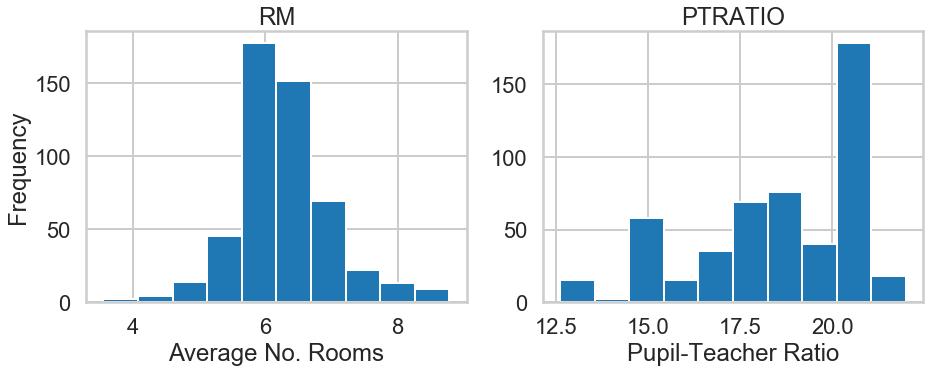

```python
h_RM_PT, (RM, PT) = plt.subplots(ncols=2)
h_RM_PT.set_size_inches(15,5)

RM.hist(bos.RM)
RM.set_title("RM")
RM.set_xlabel("Average No. Rooms")
RM.set_ylabel("Frequency")

PT.hist(bos.PTRATIO)
PT.set_title("PTRATIO")
PT.set_xlabel("Pupil-Teacher Ratio")

plt.show()
```

**No. Rooms vs. PT Ratio Analysis**

> After plotting the histograms of both variables, it can be seen that while the average number of rooms seems normally distributed, the pupil to teacher ratio does not. The average number of rooms observed center around 6, and the pupil to teacher ratio values are close to being centered around a value of 19. However, in the pupil to teacher ratio histogram, there are three peaks preventing the PT ratio histogram from representing a normal distribution, with the biggest frequency peak corresponding to about a 21 PT ratio.

### 2.3.3. Lower Status vs. Accessibility to Radial Highways

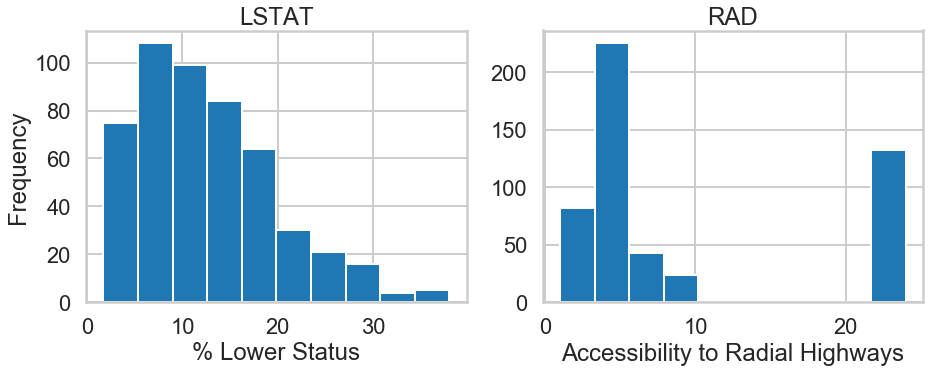

```python
h_LSTAT_RAD, (LSTAT, RAD) = plt.subplots(ncols=2)
h_LSTAT_RAD.set_size_inches(15,5)

LSTAT.hist(bos.LSTAT)
LSTAT.set_title("LSTAT")
LSTAT.set_xlabel("% Lower Status")
LSTAT.set_ylabel("Frequency")

RAD.hist(bos.RAD)
RAD.set_title("RAD")
RAD.set_xlabel("Accessibility to Radial Highways")

plt.show()
```

**Lower Status vs. Accessibility to Radial Highways**

> Both the LSTAT and RAD histograms seem positively skewed, except for the RAD histogram containing lone-standing index values of 24. The lower the LSTAT and RAD values, the better a neighborhood is considered, and therefore, it can be assumed that when it comes to a lower status population and the population's access to radial highways, Boston consistently scores on the lower end of the spectrum for both. However, there is a significant portion of Boston's houses that have very poor access to the city's radial highways.

# 3. Linear Regression with Boston Housing Data Example

Here,

$Y$ = boston housing prices (called "target" data in python, and referred to as the dependent variable or response variable)

and

$X$ = all the other features (or independent variables, predictors or explanatory variables)

which we will use to fit a linear regression model and predict Boston housing prices. We will use the least-squares method to estimate the coefficients.

We'll use two ways of fitting a linear regression. We recommend the first but the second is also powerful in its features.

## 3.1. Fitting Linear Regression using `statsmodels`

[Statsmodels](http://statsmodels.sourceforge.net/) is a great Python library for a lot of basic and inferential statistics. It also provides basic regression functions using an R-like syntax, so it's commonly used by statisticians. While we don't cover statsmodels officially in the Data Science Intensive workshop, it's a good library to have in your toolbox. Here's a quick example of what you could do with it. The version of least-squares we will use in statsmodels is called *ordinary least-squares (OLS)*. There are many other versions of least-squares such as [partial least squares (PLS)](https://en.wikipedia.org/wiki/Partial_least_squares_regression) and [weighted least squares (WLS)](https://en.wikipedia.org/wiki/Iteratively_reweighted_least_squares).

```python
# Import regression modules
import statsmodels.api as sm
from statsmodels.formula.api import ols
```

#### RM Linear Regression Model

```python
# statsmodels works nicely with pandas dataframes
# The thing inside the "quotes" is called a formula, a bit on that below
m = ols('PRICE ~ RM',bos).fit()
print(m.summary())
```

```
                            OLS Regression Results
==============================================================================
Dep. Variable:                  PRICE   R-squared:                       0.484
Model:                            OLS   Adj. R-squared:                  0.483
Method:                 Least Squares   F-statistic:                     471.8
Date:                Fri, 16 Aug 2019   Prob (F-statistic):           2.49e-74
Time:                        17:56:15   Log-Likelihood:                -1673.1
No. Observations:                 506   AIC:                             3350.
Df Residuals:                     504   BIC:                             3359.
Df Model:                           1
Covariance Type:            nonrobust
==============================================================================
                 coef    std err          t      P>|t|      [0.025      0.975]
------------------------------------------------------------------------------
Intercept    -34.6706      2.650    -13.084      0.000     -39.877     -29.465
RM             9.1021      0.419     21.722      0.000       8.279       9.925
==============================================================================
Omnibus:                      102.585   Durbin-Watson:                   0.684
Prob(Omnibus):                  0.000   Jarque-Bera (JB):              612.449
Skew:                           0.726   Prob(JB):                    1.02e-133
Kurtosis:                       8.190   Cond. No.                         58.4
==============================================================================

Warnings:
[1] Standard Errors assume that the covariance matrix of the errors is correctly specified.
```

### 3.1.1. Interpreting coefficients

There is a ton of information in this output. But we'll concentrate on the coefficient table (middle table). We can interpret the `RM` coefficient (9.1021) by first noticing that the p-value (under `P>|t|`) is so small, basically zero. This means that the number of rooms, `RM`, is a statisticall significant predictor of `PRICE`. The regression coefficient for `RM` of 9.1021 means that *on average, each additional room is associated with an increase of $\$9,100$ in house price net of the other variables*. The confidence interval gives us a range of plausible values for this average change, about ($\$8,279, \$9,925$), definitely not chump change.

In general, the $\hat{\beta_i}, i > 0$ can be interpreted as the following: "A one unit increase in $x_i$ is associated with, on average, a $\hat{\beta_i}$ increase/decrease in $y$ net of all other variables."

On the other hand, the interpretation for the intercept, $\hat{\beta}_0$ is the average of $y$ given that all of the independent variables $x_i$ are 0.

### 3.1.2. `statsmodels` formulas

This formula notation will seem familiar to `R` users, but will take some getting used to for people coming from other languages or are new to statistics.

The formula gives instruction for a general structure for a regression call. For `statsmodels` (`ols` or `logit`) calls you need to have a Pandas dataframe with column names that you will add to your formula. In the below example you need a pandas data frame that includes the columns named (`Outcome`, `X1`,`X2`, ...), but you don't need to build a new dataframe for every regression. Use the same dataframe with all these things in it. The structure is very simple:

`Outcome ~ X1`

But of course we want to to be able to handle more complex models, for example multiple regression is doone like this:

`Outcome ~ X1 + X2 + X3`

In general, a formula for an OLS multiple linear regression is

`Y ~ X1 + X2 + ... + Xp`

This is the very basic structure but it should be enough to get you through the homework. Things can get much more complex. You can force statsmodels to treat variables as categorical with the `C()` function, call numpy functions to transform data such as `np.log` for extremely-skewed data, or fit a model without an intercept by including `- 1` in the formula. For a quick run-down of further uses see the `statsmodels` [help page](http://statsmodels.sourceforge.net/devel/example_formulas.html).

Let's see how our model actually fit our data. We can see below that there is a ceiling effect, we should probably look into that. Also, for large values of $Y$ we get underpredictions, most predictions are below the 45-degree gridlines.

#### RM Linear Model Predictions

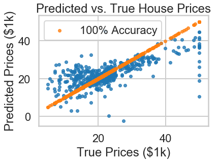

```python
pred_y = np.array(m.fittedvalues)
sns.regplot(y=pred_y, x=bos.PRICE, marker='.', fit_reg=False)
sns.regplot(y=bos.PRICE, x=bos.PRICE, marker='.', fit_reg=False, label='100% Accuracy')
plt.legend()
plt.xlabel("True Prices ($1k)")
plt.ylabel("Predicted Prices ($1k)")
plt.title("Predicted vs. True House Prices")


plt.show()
```

**Predicted Prices vs. True Prices (using Rooms)**

> The orange line represents what the scatter plot would look like if the model predicted the Boston house prices perfectly. However, in blue, it can be seen the actual inaccuracies made by the linear regression model; it makes sense that the model did not predict the true Boston house prices close to perfect, because it only relied on the number of rooms in the house. Using only the rooms, the model was able to capture a big part of what decides the price of a house, but there are some inaccuracies, especially near the lower prices and higher end proces. It seems like the regression model overpredicted a house's price much more when the houses' prices were on the lower end of the spectrum, but underpredicted the value of many of the houses that reached the \$50,000 price. The underprediction of expensive houses is probably correlated with the observations made on scatterplot 2.2.2., where there were a couple of houses with the \\$50k price that did not follow the increasing price trend as number of rooms increased; however, those houses were not high enough in quantity to affect the weights of the fitted model which is why the fitted model constantly underpredicted the \$50k priced houses. Moreover, the fitted model predicted two houses to have close to zero and negative prices which is impossible; setting constraints on future models could prove useful, so predicted values fall within an acceptable range. For our final predictive model we will want to use more house features than just the average number of rooms.

## 3.2. Fitting Linear Regression using `sklearn`

### 3.2.1. What can you do with a LinearRegression object?

Check out the scikit-learn [docs here](http://scikit-learn.org/stable/modules/generated/sklearn.linear_model.LinearRegression.html). We have listed the main functions here. Most machine learning models in scikit-learn follow this same API of fitting a model with `fit`, making predictions with `predict` and the appropriate scoring function `score` for each model.

```python
from sklearn.linear_model import LinearRegression
X = bos.drop('PRICE', axis = 1)

# This creates a LinearRegression object
lm = LinearRegression()
```

| Main functions | Description |
| --- | --- |
| `lm.fit()` | Fit a linear model |
| `lm.predit()` | Predict Y using the linear model with estimated coefficients |
| `lm.score()` | Returns the coefficient of determination (R^2). *A measure of how well observed outcomes are replicated by the model, as the proportion of total variation of outcomes explained by the model* |

### 3.2.2. Fit a linear model

The `lm.fit()` function estimates the coefficients the linear regression using least squares.

```python
# Use all 13 predictors to fit linear regression model
lm.fit(X, bos.PRICE)

# What output can you get?
list(vars(lm).keys())
```

```
['fit_intercept',
 'normalize',
 'copy_X',
 'n_jobs',
 'coef_',
 '_residues',
 'rank_',
 'singular_',
 'intercept_']
```

| Output | Description |
| --- | --- |
| `lm.coef_` | Estimated coefficients |
| `lm.intercept_` | Estimated intercept |

**Intercept Term Analysis**

> Scikit-learn's linear regression object has a parameter `fit_intercept` that sets whether or not to use a y-intercept in predictions; if this parameter is set to False, the y-intercept will be essentially zero. This is useful for situations where you already have a model making predictions, but you would like to add in another variable through the use of another model without changing the original model; there, you would want to set `fit_intercept` to False, because you already have predictions centered around the common house values and only want to factor in another variable.

**Independently and Identically Distributed (i.i.d.) Analysis**

> In order for a linear regression model to do a fairly good job at predicting target variables, it is logical for the residuals to be normally distributed, because normally distributed residuals means that the prediction line would symmetrically dissect the observed targets. However, having normally distributed residuals is not the only condition needed for the assumption of residuals being independently and identically distributed, or i.i.d. for short, to be met, because residuals being normally distributed only fulfills the identically distributed aspect of the i.i.d. assumption. The independent aspect of the i.i.d. is met when you have residuals that are not correlated with one another; for example, if the target variables were correlated to one another with respect to time, as is seen in time series data, the residuals acquired by the linear model would also be correlated with one another with respect to time, and this would violate the independent aspect of the i.i.d. assumption. Luckily, the features used to predict the Boston house prices are independent of one another, and the house prices are, therefore, also independent of one another. Even though the target variable being predicted has to be independently distributed for the residuals to meet the independent aspect of the i.i.d. assumption, the target variable does not have to be normally distributed for the identically distributed aspect of the residuals' i.i.d. assumption to be met. The reason for this is that the linear model's only goal is to minimize the least squares which is calculated one target variable at a time due to the met independent condition of i.i.d., and therefore, the overall distribution of the target variable is not taken into consideration by the linear regression model.

### 3.2.3. Estimated intercept and coefficients

Let's look at the estimated coefficients from the linear model using `1m.intercept_` and `lm.coef_`.

After we have fit our linear regression model using the least squares method, we want to see what are the estimates of our coefficients $\beta_0$, $\beta_1$, ..., $\beta_{13}$:

$$ \hat{\beta}_0, \hat{\beta}_1, \ldots, \hat{\beta}_{13} $$

```python
print('Estimated intercept coefficient: {:.2f}'.format(lm.intercept_))
print('Number of coefficients: {}'.format(lm.rank_))

# The coefficients
pd.DataFrame({'features': X.columns, 'estimatedCoefficients': lm.coef_})[['features', 'estimatedCoefficients']]
```

```
Estimated intercept coefficient: 36.46
Number of coefficients: 13
```

|  | features | estimatedCoefficients |
| --- | --- | --- |
| 0 | CRIM | -0.108011 |
| 1 | ZN | 0.046420 |
| 2 | INDUS | 0.020559 |
| 3 | CHAS | 2.686734 |
| 4 | NOX | -17.766611 |
| 5 | RM | 3.809865 |
| 6 | AGE | 0.000692 |
| 7 | DIS | -1.475567 |
| 8 | RAD | 0.306049 |
| 9 | TAX | -0.012335 |
| 10 | PTRATIO | -0.952747 |
| 11 | B | 0.009312 |
| 12 | LSTAT | -0.524758 |

### 3.2.4. Predict Prices

We can calculate the predicted prices ($\hat{Y}_i$) using `lm.predict`.

$$ \hat{Y}_i = \hat{\beta}_0 + \hat{\beta}_1 X_1 + \ldots \hat{\beta}_{13} X_{13} $$

```python
lm_pred = lm.predict(X)

# first five predicted prices
print("First Five Predicted Prices ($1k): {}".format(list(np.round(lm_pred[0:5], 2))))

# R^2 linear model score
print("\nR^2 Score: {:.3f}".format(lm.score(X, bos.PRICE)))
```

```
First Five Predicted Prices ($1k): [30.0, 25.03, 30.57, 28.61, 27.94]

R^2 Score: 0.741
```

#### LM's Predicted Prices Histogram

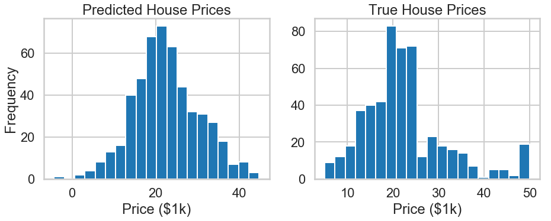

```python
h_prices, (pred, true) = plt.subplots(ncols=2)
h_prices.set_size_inches(15,5)

pred.hist(lm_pred, bins=20)
pred.set_title("Predicted House Prices")
pred.set_xlabel("Price ($1k)")
pred.set_ylabel("Frequency")

true.hist(bos.PRICE, bins=20)
true.set_title("True House Prices")
true.set_xlabel("Price ($1k)")

plt.show()
```

**LM Prices Histogram Analysis**

> Due to linear model's inability to capture non-linear relationships, when attempting to represent a population, the model is forced to compromise on some target value estimates in order to minimize the overall sum of square residuals. Therefore, as it can be seen in the linear model's predicted house prices, the linear model constantly undervalues \$50k homes and ignores the observed house price minimum of \\$5k; the linear model goes as far as predicting negative house prices. This behavior can be attributed to the distribution of the observed target prices provided to the linear regressor, because as it can be seen from the true house price histogram, the majority of observed target prices concentrate around the \$20k price tag. Therefore, in order to minimize the sum of squared residuals, the linear model has to adjust its weights to cater to prices close to \\$20k which are highly seen and compromise on less seen price values which do not add to the error as much as the highly encountered ones. Finally, the reason for the negative predicted price values can be attributed to the rigidity of a linear model which arrives at a prediction using a straight line, even when the feature and target relationship is not linear.

#### LM's Predicted Prices Scatterplot

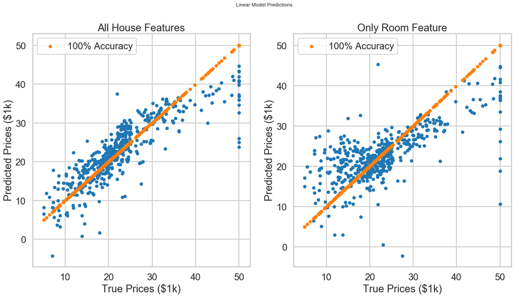

```python
s_prices, (x_13, x_1) = plt.subplots(ncols=2)
s_prices.set_size_inches(20,10)

x_13.scatter(y=lm_pred, x=bos.PRICE, marker='.')
x_13.scatter(y=bos.PRICE, x=bos.PRICE, marker='.', label='100% Accuracy')
x_13.legend()
x_13.set_xlabel("True Prices ($1k)")
x_13.set_ylabel("Predicted Prices ($1k)")
x_13.set_title("All House Features")

x_1.scatter(y=pred_y, x=bos.PRICE, marker='.')
x_1.scatter(y=bos.PRICE, x=bos.PRICE, marker='.', label='100% Accuracy')
x_1.legend()
x_1.set_xlabel("True Prices ($1k)")
x_1.set_ylabel("Predicted Prices ($1k)")
x_1.set_title("Only Room Feature")

s_prices.suptitle('Linear Model Predictions')
plt.show()
```

**LM Price Predictions Scatterplot Analysis**

> The scatterplots above compare the linear model's predicted Boston house prices with the true Boston house prices; the left scatterplot shows the least squares fit using all 13 house features, and the right scatterplot displays the comparison produced in sections 3.1.2 which only used the number of rooms to predict the target house price. As it can be seen, after taking into account all of the house features, the linear model was able to predict the Boston house price much better than when only the room feature was used; the closer the blue dots are to the orange scatterplot line, the closer the linear model got to predicting the correct price of a house. However, as discussed in the `LM Prices Histogram Analysis`, the full linear model still undervalued many of the houses at the expensive end and some of the houses on the lower end. The linear model's desire to minimize its sum of squared residuals by catering towards the house price values it saw most often, e.g. houses in the \$20k price range, can be seen more clearly; the scatterplot shows the observation density of those houses compared to the most and least expensive houses.

### 3.2.5. Evaluating the Model: Sum-of-Squares

The partitioning of the sum-of-squares shows the variance in the predictions explained by the model and the variance that is attributed to error.

$$TSS = ESS + RSS = \sum_{i=1}^N \left(y_i - \bar{y} \right)^2$$

#### Residual Sum-of-Squares (aka $RSS$)

The residual sum-of-squares is one of the basic ways of quantifying how much error exists in the fitted model. We will revisit this in a bit.

$$ RSS = \sum_{i=1}^N r_i^2 = \sum_{i=1}^N \left(y_i - \left(\beta_0 + \beta_1 x_i\right)\right)^2$$

```python
RSS = np.round(np.sum((bos.PRICE - lm.predict(X)) ** 2), 2)
print('RSS =', RSS)
```

```
RSS = 11078.78
```

#### Explained Sum-of-Squares (aka $ESS$)

The explained sum-of-squares measures the variance explained by the regression model.

$$ESS = \sum_{i=1}^N \left( \hat{y}_i - \bar{y} \right)^2 = \sum_{i=1}^N \left( \left( \hat{\beta}_0 + \hat{\beta}_1 x_i \right) - \bar{y} \right)^2$$

```python
ESS = np.round(np.sum((lm.predict(X) - np.mean(bos.PRICE)) ** 2), 2)
print('ESS =', ESS)
```

```
ESS = 31637.51
```

### 3.2.6. Evaluating the Model: The Coefficient of Determination ($R^2$)

The coefficient of determination, $R^2$, tells us the percentage of the variance in the response variable $Y$ that can be explained by the linear regression model.

$$ R^2 = 1 - \frac{RSS}{TSS} = \frac{ESS}{TSS}$$

The $R^2$ value is one of the most common metrics that people use in describing the quality of a model, but it is important to note that *$R^2$ increases artificially as a side-effect of increasing the number of independent variables.* While $R^2$ is reported in almost all statistical packages, another metric called the *adjusted $R^2$* is also provided as it takes into account the number of variables in the model, and can sometimes even be used for non-linear regression models!

$$R_{adj}^2 = 1 - \left( 1 - R^2 \right) \frac{N - 1}{N - K - 1} = R^2 - \left( 1 - R^2 \right) \frac{K}{N - K - 1} = 1 - \frac{\frac{RSS}{DF_R}}{\frac{TSS}{DF_T}}$$

where $N$ is the number of observations, $K$ is the number of variables, $DF_R = N - K - 1$ is the degrees of freedom associated with the residual error and $DF_T = N - 1$ is the degrees of the freedom of the total error.

### 3.2.7. Evaluating the Model: Mean Squared Error and the $F$-Statistic

The mean squared errors are just the *averages* of the sum-of-squares errors over their respective degrees of freedom.

$$MSE = \frac{RSS}{N-K-1}$$

$$MSR = \frac{ESS}{K}$$

**Remember:** Notation may vary across resources particularly the use of $R$ and $E$ in $RSS/ESS$ and $MSR/MSE$. In some resources, E = explained and R = residual. In other resources, E = error and R = regression (explained). **This is a very important distinction that requires looking at the formula to determine which naming scheme is being used.**

Given the MSR and MSE, we can now determine whether or not the entire model we just fit is even statistically significant. We use an $F$-test for this. The null hypothesis is that all of the $\beta$ coefficients are zero, that is, none of them have any effect on $Y$. The alternative is that *at least one* $\beta$ coefficient is nonzero, but it doesn't tell us which one in a multiple regression:

$$H_0: \beta_i = 0, \mbox{for all $i$} \\ H_A: \beta_i > 0, \mbox{for some $i$}$$

$$F = \frac{MSR}{MSE} = \left( \frac{R^2}{1 - R^2} \right) \left( \frac{N - K - 1}{K} \right)$$

Once we compute the $F$-statistic, we can use the $F$-distribution with $N-K$ and $K-1$ degrees of degrees of freedom to get a p-value.

**Warning!** The $F$-statistic mentioned in this section is NOT the same as the F1-measure or F1-value.

#### PTRATIO

```python
# PTRATIO vs. Price
m_PT = ols('PRICE ~ PTRATIO',bos).fit()
print(m_PT.summary())
```

```
                            OLS Regression Results
==============================================================================
Dep. Variable:                  PRICE   R-squared:                       0.258
Model:                            OLS   Adj. R-squared:                  0.256
Method:                 Least Squares   F-statistic:                     175.1
Date:                Fri, 16 Aug 2019   Prob (F-statistic):           1.61e-34
Time:                        17:56:18   Log-Likelihood:                -1764.8
No. Observations:                 506   AIC:                             3534.
Df Residuals:                     504   BIC:                             3542.
Df Model:                           1
Covariance Type:            nonrobust
==============================================================================
                 coef    std err          t      P>|t|      [0.025      0.975]
------------------------------------------------------------------------------
Intercept     62.3446      3.029     20.581      0.000      56.393      68.296
PTRATIO       -2.1572      0.163    -13.233      0.000      -2.477      -1.837
==============================================================================
Omnibus:                       92.924   Durbin-Watson:                   0.725
Prob(Omnibus):                  0.000   Jarque-Bera (JB):              191.444
Skew:                           1.001   Prob(JB):                     2.68e-42
Kurtosis:                       5.252   Cond. No.                         160.
==============================================================================

Warnings:
[1] Standard Errors assume that the covariance matrix of the errors is correctly specified.
```

**Coefficients & Intercept Analysis**

> The coefficient derived for PTRATIO is -2.1573 which means that for every additional student a teacher is responsible of, the price of the house decreases on average by \$2,157.30. The intercept acquired has a value corresponding to a house price of \\$62, 344.60 and lets us know what starting price of a house is. The reason for the intercept being such a high value is that PTRATIO is always positive and can only make the house price decrease due to its assigned negative coefficient; if the intercept was zero, for example, the linear model would constantly predict negative house prices which would lead to very poor performance.

**R-Squared & F-statistic Analysis**

> We can measure a model's performance using the R-squared metric. The R-squared metric tells us how much of the variance was captured by the model; a value of 1 indicates the maximum R-square score a model can get which means the model predicted all of the observed data points perfectly, and a value of 0 means that the model did just as well as if the prediction was made at random. Further, a negative R-squared value means that the model is really doing bad to the point where it would have achieved a better performance if it had arrived at predictions randomly; for example, if a target value increases as a predictor variable increases, but the model predicts the target value to decrease as the predictor variable increases, that model will probably have a negative R-squared score. The linear model using PTRATIO only to predict Boston house prices achieved an R-squared score of 0.258 which means it performed better than random predictions but missed more than 70% of the dataset's variation, i.e. poor performance. The F-statistic now tells us how credible the fit of the linear regression model is; the F-statistic takes into consideration the number of observations, number of features and the R-squared score. The probability of the model being statistically significant increases as the observations increase, features decrease and R-squared score gets closer to 1. The F-statistic is then used to acquire the probability that the observations and features used acquired the R-squared score by luck; if the probability is higher than 0.05, we can accept this hypothesis, but if its lower, we can reject the hypothesis and assume that the linear model has predictor capabilities able to predict the target variable better than random. In this case, the linear model got an F-statistic of 175.1 which corresponded to a probability of 1.61e-34; therefore, we can reject the belief that the linear model's coefficient assigned to PTRATIO has no effect on the price of a house and assume there is a predictive relationship there. In a simple linear regression model, the t-statistic for the only predictor can be obtained by taking the square root of the F-statistic, because the F-statistic is calculated using the slope of the only predictor which in this case is PTRATIO.

#### PTRATIO + CRIM + RM

```python
# PTRATIO, CRIM, RM vs. Price
m_CRP = ols('PRICE ~ PTRATIO + CRIM + RM',bos).fit()
print(m_CRP.summary())
```

```
                            OLS Regression Results
==============================================================================
Dep. Variable:                  PRICE   R-squared:                       0.594
Model:                            OLS   Adj. R-squared:                  0.592
Method:                 Least Squares   F-statistic:                     245.2
Date:                Fri, 16 Aug 2019   Prob (F-statistic):           6.15e-98
Time:                        17:56:18   Log-Likelihood:                -1612.0
No. Observations:                 506   AIC:                             3232.
Df Residuals:                     502   BIC:                             3249.
Df Model:                           3
Covariance Type:            nonrobust
==============================================================================
                 coef    std err          t      P>|t|      [0.025      0.975]
------------------------------------------------------------------------------
Intercept     -3.3707      4.034     -0.836      0.404     -11.296       4.555
PTRATIO       -1.0695      0.133     -8.051      0.000      -1.331      -0.809
CRIM          -0.2050      0.032     -6.399      0.000      -0.268      -0.142
RM             7.3804      0.402     18.382      0.000       6.592       8.169
==============================================================================
Omnibus:                      234.656   Durbin-Watson:                   0.830
Prob(Omnibus):                  0.000   Jarque-Bera (JB):             2020.689
Skew:                           1.815   Prob(JB):                         0.00
Kurtosis:                      12.092   Cond. No.                         311.
==============================================================================

Warnings:
[1] Standard Errors assume that the covariance matrix of the errors is correctly specified.
```

# 4. Comparing Models

During modeling, there will be times when we want to compare models to see which one is more predictive or fits the data better. There are many ways to compare models, but we will focus on two.

## 4.1. The $F$-Statistic Revisited

The $F$-statistic can also be used to compare two *nested* models, that is, two models trained on the same dataset where one of the models contains a *subset* of the variables of the other model. The *full* model contains $K$ variables and the *reduced* model contains a subset of these $K$ variables. This allows us to add additional variables to a base model and then test if adding the variables helped the model fit.

$$F = \frac{\left( \frac{RSS_{reduced} - RSS_{full}}{DF_{reduced} - DF_{full}} \right)}{\left( \frac{RSS_{full}}{DF_{full}} \right)}$$

where $DF_x = N - K_x - 1$ where $K_x$ is the number of variables in model $x$.

## 4.2. Akaike Information Criterion (AIC)

Another statistic for comparing two models is AIC, which is based on the likelihood function and takes into account the number of variables in the model.

$$AIC = 2 K - 2 \log_e{L}$$

where $L$ is the likelihood of the model. AIC is meaningless in the absolute sense, and is only meaningful when compared to AIC values from other models. Lower values of AIC indicate better fitting models.

`statsmodels` provides the AIC in its output.

#### PTRATIO + CRIM + RM + LSTAT + DIS

```python
m_five = ols('PRICE ~ PTRATIO + CRIM + RM + LSTAT + DIS', data=bos).fit()
print(m_five.summary())
```

```
                            OLS Regression Results
==============================================================================
Dep. Variable:                  PRICE   R-squared:                       0.696
Model:                            OLS   Adj. R-squared:                  0.693
Method:                 Least Squares   F-statistic:                     228.7
Date:                Fri, 16 Aug 2019   Prob (F-statistic):          1.10e-126
Time:                        17:56:18   Log-Likelihood:                -1539.2
No. Observations:                 506   AIC:                             3090.
Df Residuals:                     500   BIC:                             3116.
Df Model:                           5
Covariance Type:            nonrobust
==============================================================================
                 coef    std err          t      P>|t|      [0.025      0.975]
------------------------------------------------------------------------------
Intercept     22.8945      4.080      5.611      0.000      14.879      30.910
PTRATIO       -0.9214      0.116     -7.914      0.000      -1.150      -0.693
CRIM          -0.0918      0.031     -2.998      0.003      -0.152      -0.032
RM             4.3326      0.422     10.266      0.000       3.503       5.162
LSTAT         -0.6244      0.048    -12.911      0.000      -0.719      -0.529
DIS           -0.6201      0.128     -4.845      0.000      -0.872      -0.369
==============================================================================
Omnibus:                      182.594   Durbin-Watson:                   0.960
Prob(Omnibus):                  0.000   Jarque-Bera (JB):              810.523
Skew:                           1.561   Prob(JB):                    9.93e-177
Kurtosis:                       8.357   Cond. No.                         442.
==============================================================================

Warnings:
[1] Standard Errors assume that the covariance matrix of the errors is correctly specified.
```

#### Full vs. Reduced Model Performance

```python
RSS_red = np.sum((m_CRP.resid)**2)
RSS_full = np.sum((m_five.resid)**2)
DF_red = m_CRP.df_resid
DF_full = m_five.df_resid
F_stat = ((RSS_red - RSS_full) / (DF_red - DF_full)) / (RSS_full / DF_full)
print('F-Statistic: {:.2f}'.format(F_stat))
Prob = 1 - stats.f.cdf(F_stat, DF_red, DF_full)
print('Prob (F-statistic): {:.2e}'.format(Prob))
print('--------------------------------------------')
print('    Five Variable (Full) Model AIC: {:.2f}'.format(m_five.aic))
print('Three Variable (Reduced) Model AIC: {:.2f}'.format(m_CRP.aic))
```

```
F-Statistic: 83.35
Prob (F-statistic): 1.11e-16
--------------------------------------------
    Five Variable (Full) Model AIC: 3090.35
Three Variable (Reduced) Model AIC: 3231.95
```

# 5. Evaluating the Model via Model Assumptions and Other Issues

## 5.1. Model Assumptions

Linear regression makes several assumptions. It is always best to check that these assumptions are valid after fitting a linear regression model.

**Linearity**

> The dependent variable $Y$ is a linear combination of the regression coefficients and the independent variables $X$. This can be verified with a scatterplot of each $X$ vs. $Y$ and plotting correlations among $X$. Nonlinearity can sometimes be resolved by [transforming](https://onlinecourses.science.psu.edu/stat501/node/318) one or more independent variables, the dependent variable, or both. In other cases, a [generalized linear model](https://en.wikipedia.org/wiki/Generalized_linear_model) or a [nonlinear model](https://en.wikipedia.org/wiki/Nonlinear_regression) may be warranted.

**Constant standard deviation**

> The SD of the dependent variable $Y$ should be constant for different values of X. We can check this by plotting each $X$ against $Y$ and verifying that there is no "funnel" shape showing data points fanning out as $X$ increases or decreases. Some techniques for dealing with non-constant variance include weighted least squares (WLS), [robust standard errors](https://en.wikipedia.org/wiki/Heteroscedasticity-consistent_standard_errors), or variance stabilizing transformations.

**Normal distribution for errors**

> The $\epsilon$ term we discussed at the beginning are assumed to be normally distributed. This can be verified with a fitted values vs. residuals plot and verifying that there is no pattern, and with a quantile plot. $$ \epsilon_i \sim N(0, \sigma^2)$$ Sometimes the distributions of responses $Y$ may not be normally distributed at any given value of $X$. e.g. skewed positively or negatively.

**Independent errors**

> The observations are assumed to be obtained independently; e.g. Observations across time may be correlated

## 5.2. Other Issues

There are some other issues that are important investigate with linear regression models.

**Correlated Predictors**

> Care should be taken to make sure that the independent variables in a regression model are not too highly correlated. Correlated predictors typically do not majorly affect prediction, but do inflate standard errors of coefficients making interpretation unreliable. Common solutions are dropping the least important variables involved in the correlations, using regularlization, or, when many predictors are highly correlated, considering a dimension reduction technique such as principal component analysis (PCA).

**Influential Points**

> Data points that have undue influence on the regression model. These points can be high leverage points or outliers. Such points are typically removed and the regression model rerun.

## 5.3. Using Residuals to Assess & Improve Model Performance

### 5.3.1 Residual Plots

Residual plots will be based on linear regression model using `CRIM`, `PTRATIO` and `RM` features to predict Boston house prices.

#### Fitted Values vs. Quantile Plots

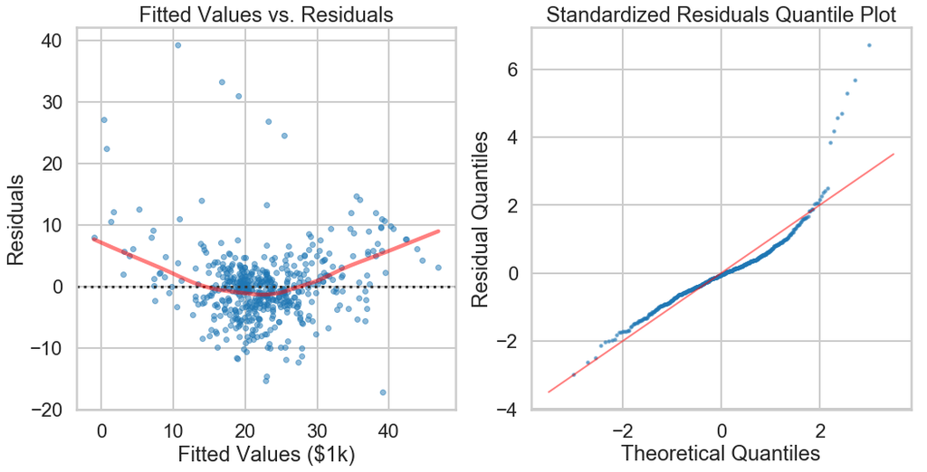

```python
from sklearn.preprocessing import normalize
from statsmodels.graphics.gofplots import ProbPlot

plt.rcParams["figure.figsize"] = [17, 8]

plt.subplot(1,2,1)
sns.residplot(y=m_CRP.resid, x=m_CRP.fittedvalues, lowess=True,
              scatter_kws={'marker':'.', 'alpha':0.5},
              line_kws={'color':'r', 'alpha':0.5})
plt.xlabel('Fitted Values ($1k)')
plt.ylabel('Residuals')
plt.title('Fitted Values vs. Residuals')

plt.subplot(1,2,2)
influence = m_CRP.get_influence()
stand_resid = influence.resid_studentized_internal
q_stats = stats.probplot(stand_resid)[0]

plt.scatter(q_stats[0], q_stats[1],
            marker='.', alpha=0.5, s=30)
plt.plot([-3.5, 3.5], [-3.5, 3.5],
         color='r', linewidth=2, alpha=0.5)
plt.title('Standardized Residuals Quantile Plot')
plt.xlabel('Theoretical Quantiles')
plt.ylabel('Residual Quantiles')

plt.show()
```

**Fitted Values vs. Residuals**

> The fitted values vs. residuals plot allows us to see where the average residual value lies for every price value predicted by the linear regression model, and in this case, it can be seen how the average residual value around the extreme ends of the predicted prices diverge strongly from a residual value of zero. The residuals at the extremes are positive which means that the linear model is constantly underpredicting the house prices at both ends. This is due to the linear model's attempt to linearly fit data that is not linearly separable and make residuals normally distributed; this causes the predicted values to follow a rigid linear regression line that undervalues houses at both ends of the spectrum. Further, the rigidity of the linear model causes it to place a higher importance on predicted values around \$20,000 where the residuals are closer to zero, even if it means it will receive a high penalty for the higher residual values seen at the extreme house prices, because the impact of those higher residuals does not outweigh the impact caused by the cluster of residuals corresponding to house prices around \\$20,000.

**Standardized Residuals Quantile Plot**

> A quantile plot shows what perfectly normally distributed residuals would look like (red line) and shows us the actual distribution followed by the residuals (blue scatter plot). The same pattern seen in the fitted values plot can be seen in the quantile plot, where the linear model underpredicts the house values at the low and high price values; this is shown by the blue scatter points above the red line. The quantile plot showcases the linear model's goal to make the residuals normally distributed, since the residuals distribution does have a mean of zero.

**Advantages and Disadvantages of Both Plots**

> The advantage of a fitted values vs. residuals plot is that you are able to see the range of the residuals and how bad the linear model's mistakes are; for example, it can be seen that there are a few residual outliers that indicate a prediction mistake of +\$20,000 dollars. These outliers will be further examined in the next section where we will decide if some observations should be removed, in order to improve the linear model's performance. Also, the fitted values vs. residuals allows us to see where the biggest mistakes are being made, because you can take the fitted value and add the residual to see what the true house price was. For example, one of the biggest resdiuals has a value of 40 which means that the linear model undervalued the house by \\$40,000, and after adding this residual to the fitted value, we can see that the actual house price was \$50,000 but was predicted to be \\$10,000; this is just one of the examples where the linear model compromises on values on the extreme ends of the price spectrum, even if it leads to large residuals. A disadvantage of the fitted values vs. resdiuals is that it does not really emphasize the distribution of the residuals and that is where the quantile plot comes in. The quantile plot emphasizes where the residuals deviate from normality by plotting them against a line representing a perfect normal distribution; for example, the quantile plot lets us see how the linear model's residuals deviate strongly from the normal distribution, especially as the standardized residuals reach a value of 4, but as it can be seen from the quantile plot, there is very few residuals deviating from normality which is due to the very few observations of houses, specifically the \$50,000 houses, that really deviated from the linear model's fitted line. We are now going to plot a leverage and cook's distance plot to take a closer look at the observations causing the residual outliers and see how it affects the model's performance if they are removed.

#### Leverage and Cook's Distance Plots

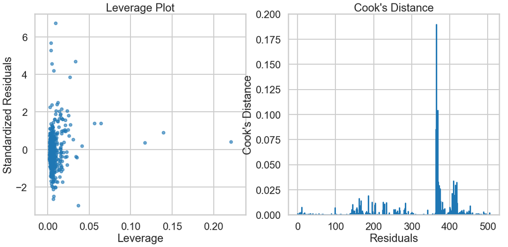

```
Feature Statistics:

               CRIM      RM  PTRATIO    PRICE
Mean        3.6135  6.2846  18.4555  22.5328
Median      0.2565  6.2085  19.0500  21.2000
3rd Quant.  3.6771  6.6235  20.2000  25.0000


High Leverage Observations:

         CRIM     RM  PTRATIO  PRICE  PRED  RES
380  88.9762  6.968     20.2   10.4   8.2  2.2
405  67.9208  5.683     20.2    5.0   3.0  2.0
410  51.1358  5.757     20.2   15.0   7.0  8.0
414  45.7461  4.519     20.2    7.0  -1.0  8.0
418  73.5341  5.957     20.2    8.8   3.9  4.9


Residual Outliers:

          CRIM     RM  PTRATIO  PRICE  PRED   RES
364   3.47428  8.780     20.2   21.9  39.1 -17.2
365   4.55587  3.561     20.2   27.5   0.4  27.1
367  13.52220  3.863     20.2   23.1   0.8  22.3
368   4.89822  4.970     20.2   50.0  10.7  39.3
```

```python
from sklearn.preprocessing import normalize
from statsmodels.graphics.gofplots import ProbPlot

plt.rcParams["figure.figsize"] = [18, 8]

plt.subplot(1,2,1)
leverage = influence.hat_matrix_diag
plt.scatter(y=stand_resid, x=leverage,
            marker='.', alpha=0.6)
plt.xlabel('Leverage')
plt.ylabel('Standardized Residuals')
plt.title('Leverage Plot')

plt.subplot(1,2,2)
cooks_dist = influence.cooks_distance[0]
plt.stem(range(len(bos)), cooks_dist,
         markerfmt=',', bottom=-1)
plt.ylim(0, 0.2)
plt.title("Cook's Distance")
plt.xlabel('Residuals')
plt.ylabel("Cook's Distance")

plt.show()
imp_stat = np.round(bos.iloc[:, [0, 5, 10, 13]].describe().iloc[[1, 5, 6]], 4)
imp_stat = imp_stat.rename(index={'mean':'Mean', '50%':'Median', '75%':'3rd Quant.'})
print('Feature Statistics:\n\n', imp_stat)

hlev_ix = np.where(leverage > 0.05)[0]
high_lev = bos.iloc[hlev_ix, [0, 5, 10, 13]]
high_lev['PRED'] = np.round(m_CRP.fittedvalues.iloc[hlev_ix], 1)
high_lev['RES'] = np.round(m_CRP.resid.iloc[hlev_ix], 1)
print('\n\nHigh Leverage Observations:\n\n', high_lev)

out_ix = np.where(cooks_dist > 0.05)[0]
outliers = bos.iloc[out_ix, [0, 5, 10, 13]]
outliers['PRED'] = np.round(m_CRP.fittedvalues.iloc[out_ix], 1)
outliers['RES'] = np.round(m_CRP.resid.iloc[out_ix], 1)
print('\n\nResidual Outliers:\n\n', outliers)
```

**Leverage Plot**

> The leverage plot allows us to see observations with leverage outliers; leverage lets us know what observations contain feature values that are way higher or lower than the average observation. Therefore, by looking at the leverage plot, we can see how there are five observations that have a leverage higher than 0.05, and after further inspection it can be seen that the values recorded for their CRIM feature is what is causing the high leverage. From the feature statistics table, it can be seen that the average observation has a CRIM value of 3.61; half of the observations have a CRIM value below 0.26; and 75% of all observations have a CRIM value less than 3.68. Then, looking at the high leverage observations table, we can see how the observations corresponding to a leverage value greater than 0.05 have CRIM values way higher than the rest; this causes the linear model to constantly underpredict the house price which affects the fit of the model when it tries to compensate for those underpredictions. We will remove those observations with high leverage in the next step and see how it affects the linear model's performance.

**Cook's Distance**

> The cook's distance allows us to see some of the observations' residuals that are disproportionately bigger than the rest, and therefore, even if in small quantity, these observations have a large influence in the final fit of the linear model. In order to stop any one observation from influencing the linear model too much, we will remove the observations with a cook's distance greater than 0.05; those observations can be seen in the residual outliers table. After observing this table, it can be noted that the `RM` feature appears to be causing the great residuals in predictions, because their room values and their corresponding price values do not follow the trend originally described where house prices should go up as rooms increase. Therefore, the house price for observation 364 was overvalued due to its unusually high room value but average true price; on the other hand, the rest of the observations with a high cook's distance were undervalued model due to the same reason which is that their RM value is lower than average but higher than average price. Observation 367 is also affected by its unusually high `CRIM` value, which drops the predicted price further than the actual price. These outliers will be removed in the next section, and we will see how the model's performance is affected by their removal.

### 5.3.2. Model Improvement

```python
rem_ix = np.concatenate((hlev_ix, out_ix))
rem_bos = bos.drop(rem_ix)

# PTRATIO, CRIM, RM vs. Price
m_rem = ols('PRICE ~ PTRATIO + CRIM + RM', rem_bos).fit()
print(m_rem.summary())
```

```
                            OLS Regression Results
==============================================================================
Dep. Variable:                  PRICE   R-squared:                       0.666
Model:                            OLS   Adj. R-squared:                  0.664
Method:                 Least Squares   F-statistic:                     327.5
Date:                Fri, 16 Aug 2019   Prob (F-statistic):          6.27e-117
Time:                        19:27:49   Log-Likelihood:                -1529.3
No. Observations:                 497   AIC:                             3067.
Df Residuals:                     493   BIC:                             3083.
Df Model:                           3
Covariance Type:            nonrobust
==============================================================================
                 coef    std err          t      P>|t|      [0.025      0.975]
------------------------------------------------------------------------------
Intercept    -11.9816      3.751     -3.194      0.001     -19.352      -4.611
PTRATIO       -0.9486      0.122     -7.806      0.000      -1.187      -0.710
CRIM          -0.2915      0.044     -6.609      0.000      -0.378      -0.205
RM             8.4039      0.384     21.897      0.000       7.650       9.158
==============================================================================
Omnibus:                      197.089   Durbin-Watson:                   0.867
Prob(Omnibus):                  0.000   Jarque-Bera (JB):             1468.366
Skew:                           1.537   Prob(JB):                         0.00
Kurtosis:                      10.840   Cond. No.                         317.
==============================================================================

Warnings:
[1] Standard Errors assume that the covariance matrix of the errors is correctly specified.
```